# **`The Sinking of the Titanic: Causes, Events, and Aftermath`**

```
First 5 rows of dataset:
```

|  | survived | pclass | sex | age | sibsp | parch | fare | embarked | class | who | adult_male | deck | embark_town | alive | alone |
| --- | --- | --- | --- | --- | --- | --- | --- | --- | --- | --- | --- | --- | --- | --- | --- |
| 0 | 0 | 3 | male | 22.0 | 1 | 0 | 7.2500 | S | Third | man | True | NaN | Southampton | no | False |
| 1 | 1 | 1 | female | 38.0 | 1 | 0 | 71.2833 | C | First | woman | False | C | Cherbourg | yes | False |
| 2 | 1 | 3 | female | 26.0 | 0 | 0 | 7.9250 | S | Third | woman | False | NaN | Southampton | yes | True |
| 3 | 1 | 1 | female | 35.0 | 1 | 0 | 53.1000 | S | First | woman | False | C | Southampton | yes | False |
| 4 | 0 | 3 | male | 35.0 | 0 | 0 | 8.0500 | S | Third | man | True | NaN | Southampton | no | True |

```
Shape of dataset (rows, columns):
(891, 15)

Data Types of each column:
survived          int64
pclass            int64
sex              object
age             float64
sibsp             int64
parch             int64
fare            float64
embarked         object
class          category
who              object
adult_male         bool
deck           category
embark_town      object
alive            object
alone              bool
dtype: object

Missing Values in each column:
survived         0
pclass           0
sex              0
age            177
sibsp            0
parch            0
fare             0
embarked         2
class            0
who              0
adult_male       0
deck           688
embark_town      2
alive            0
alone            0
dtype: int64
```

# **The Plot Below Shows:**

**`1. Who Lived and Who Lost Their Lives? (Survival Count)`**

**What it is:**

This is a simple bar chart that shows the total number of people who survived the disaster versus those who did not.

**The Bars:**

You will see two main bars. One represents "0" (those who sadly passed away) and the other represents "1" (those who survived).

**The Story:**

Looking at the height of the bars, you can immediately see that the bar for those who did not survive is much taller. This tells us right away that more than half of the people on the ship lost their lives.

**Why it's important:**

It acts as the "big picture" for the whole story, showing us the scale of the tragedy before we look into details like age or ticket price.

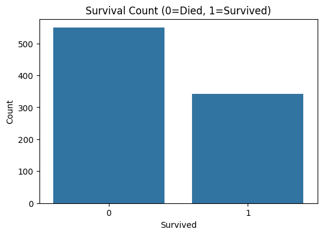

# **The Plot Below shows:**

**`2. The "Women and Children First" Rule (Survival by Gender)`**

What it is:

This is a bar chart that compares how many men and women survived versus how many did not.

The Bars:

It shows side-by-side bars for males and females.

The Story: This chart shows a very clear pattern: even though there were many more men on the ship, a much higher number of women survived.

Why it's important:

It proves that the "women and children first" policy was followed during the emergency, as females had a much higher survival rate than males.

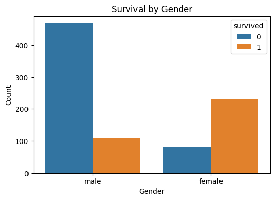

# **The Plot below Exposes:**

**`3. How Old Were the Passengers? (Age Distribution)`**

**What it is:**

This chart (called a histogram) shows the different age groups of people on the ship, from newborn babies to the elderly. The Shape: The graph looks like a mountain with a high peak. The tallest part of the "mountain" is usually between the ages of 20 and 35.

**The Story:**

It tells us that the Titanic was mostly filled with young adults. You will also notice a smaller "bump" at the very far left of the chart, which shows that there were quite a few young children and infants on board as well.

**Why it's important:**

It helps us see the "face" of the passengers. By knowing their ages, we can better understand who was most at risk and how different groups—like children—were prioritized during the rescue.

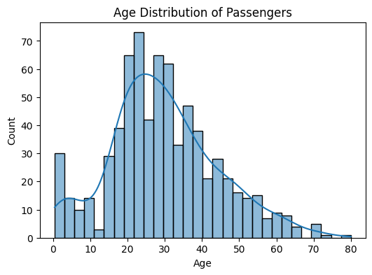

[output not shown]

```
Dataset BEFORE Preprocessing:
Shape: (891, 15)

Missing Values BEFORE:
survived         0
pclass           0
sex              0
age            177
sibsp            0
parch            0
fare             0
embarked         2
class            0
who              0
adult_male       0
deck           688
embark_town      2
alive            0
alone            0
dtype: int64
```

```
Missing values fixed successfully!
survived       0
pclass         0
sex            0
age            0
sibsp          0
parch          0
fare           0
embarked       0
class          0
who            0
adult_male     0
embark_town    2
alive          0
alone          0
dtype: int64
```

```
Encoding done successfully!
   sex  embarked
0    1         0
1    0         1
2    0         0
3    0         0
4    1         0
```

```
Scaling done successfully!
        age      fare
0 -0.565736 -0.502445
1  0.663861  0.786845
2 -0.258337 -0.488854
3  0.433312  0.420730
4  0.433312 -0.486337
```

```
Number of outliers in Fare column: 116
```

# **The Following Plot Reveals:**

**`4. Were There Any Unusually High Ticket Prices? (Outliers for Fare)`**

**What it is:**

This chart (usually a box plot) is used to find "outliers," which are data points that are very different from the rest of the group.

**The Story:**

**Why it's important:**

These dots show us the extreme gap between the richest and poorest people on the ship. It also helps researchers decide if these very high numbers might "confuse" a computer model, as they are so different from the "normal" ticket price.

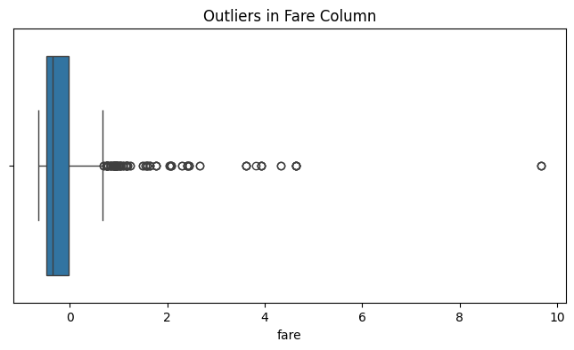

```
Shape BEFORE removing outliers: (891, 14)
Shape AFTER removing outliers: (775, 14)
```

```
Accuracy BEFORE removing outliers: 0.8100558659217877
```

```
Accuracy AFTER removing outliers: 0.7419354838709677
```

```
========================================
OUTLIER TREATMENT COMPARISON
========================================
Accuracy BEFORE removing outliers: 0.8101
Accuracy AFTER  removing outliers: 0.7419
========================================
```

```
Feature 1 - Family Size created!
Feature 2 - Is Alone created!
Feature 3 - Age Group created!
Feature 4 - Fare Per Person created!

New features added successfully!
```

|  | family_size | is_alone | age_group | fare_per_person |
| --- | --- | --- | --- | --- |
| 0 | 2 | 0 | young | -0.251223 |
| 1 | 2 | 0 | middle | 0.393423 |
| 2 | 1 | 1 | young | -0.488854 |
| 3 | 2 | 0 | middle | 0.210365 |
| 4 | 1 | 1 | middle | -0.486337 |

```
WHY THESE FEATURES ARE USEFUL
==================================================

1. FAMILY SIZE:
   Larger families may have helped each other survive

2. IS ALONE:
   Solo travellers may have had less chance of survival

3. AGE GROUP:
   Children were given priority in lifeboats

4. FARE PER PERSON:
   Higher fare means better class = better survival chance
```

```
========================================
FEATURE ENGINEERING COMPARISON
========================================
Accuracy WITHOUT new features: 0.8101
Accuracy WITH    new features: 0.7933
========================================
```

```
Training size: (712, 9)
Testing size: (179, 9)
```

```
=============================================
BASELINE MODEL RESULTS
=============================================
Accuracy: 0.7933

Detailed Report:
              precision    recall  f1-score   support

           0       0.80      0.86      0.83       105
           1       0.78      0.70      0.74        74

    accuracy                           0.79       179
   macro avg       0.79      0.78      0.78       179
weighted avg       0.79      0.79      0.79       179
```

```
BASELINE MODEL INTERPRETATION
=============================================

Model Used    : Logistic Regression
Purpose       : Predict survival (0=Died, 1=Survived)

Accuracy means: Out of every 100 passengers,
the model correctly predicts survival for ~80 of them

This is our STARTING POINT - we will now
try better models to beat this score in Q6!
```

[output not shown]

```
MODEL COMPARISON TABLE
===================================
              Model  Accuracy
Logistic Regression    0.7933
      Random Forest    0.7989
                SVM    0.8101
                KNN    0.8045
===================================
Best Model: SVM
```

# **The Plot Displays:**

**`5. Which Computer Model Guessed Best? (Model Comparison - Accuracy)`**

**What it is:**

This bar chart compares different AI or computer models to see which one was the best at "guessing" whether a passenger lived or died.

**The Bars:**

Each bar represents a different model (like a "Robot Brain"), and the height of the bar shows its Accuracy Score.

**The Story:**

A taller bar means that specific model was more successful at looking at the data—like age, gender, and ticket price—and making the correct prediction.

**Why it's important:**

It helps us pick the "winner". By comparing them side-by-side, we can choose the most reliable model to use for our final research results.

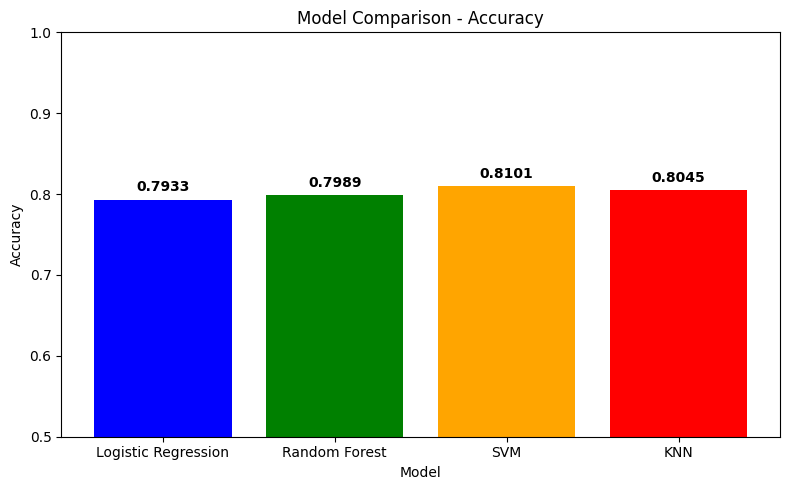

```
Fitting 5 folds for each of 36 candidates, totalling 180 fits
Tuning Complete!
```

[output not shown]

# **This Plot Shows:**

**`6. Practice vs. The Real Test (Learning Curve: Training vs. Validation)`**

**What it is:**

This line graph shows how a computer model improves as it learns from more data. It tracks two lines: one for Training (how it performs on data it has already seen) and one for Validation (how it performs on "new" data it hasn't seen before).

**The Lines:**

You will usually see two lines moving across the chart. Ideally, both lines should get closer to a high accuracy score together.

**The Story:**

It tells us if the model is actually "learning" or just "memorizing". If the Training line is perfect but the Validation line is very low, the model is like a student who memorized the practice test but fails the real exam.

**Why it's important:**

It helps us find the "sweet spot" where the model is smart enough to handle new, real-world information accurately without making silly mistakes.

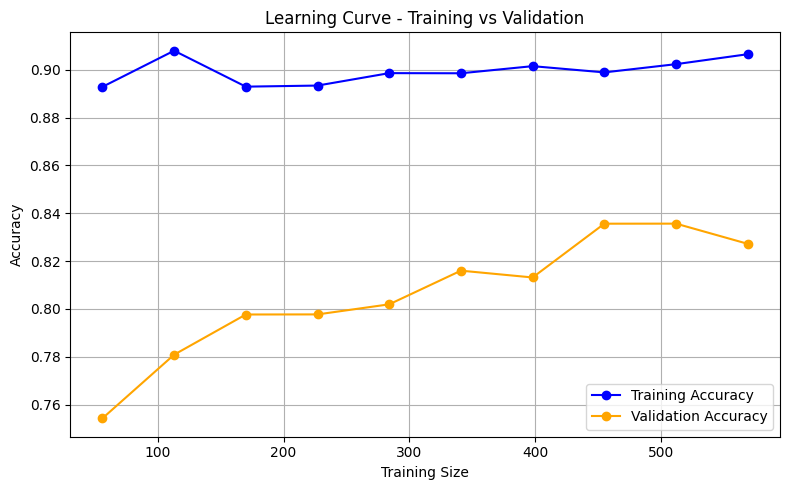

```
=============================================
OVERFITTING & UNDERFITTING ANALYSIS
=============================================

Training Accuracy  : 0.9065
Validation Accuracy: 0.8272
Difference         : 0.0793

Result: Model is BALANCED
Training and validation scores are close!
=============================================
```

```
=============================================
AFTER APPLYING FIX
=============================================
Training Accuracy: 0.8666
Testing  Accuracy: 0.7989
Difference       : 0.0677

Model is now more balanced!
=============================================
```

```
Neural Network Built Successfully!
Architecture:
Input Layer  -> 9 features
Hidden Layer 1 -> 64 neurons
Hidden Layer 2 -> 32 neurons
Output Layer -> 1 (Survived/Died)
```

[output not shown]

[output cut: 46 more lines]

[output not shown]

# **This Plot Shows off:**

**`7. The "Mistake" Tracker (Neural Network Training Loss)`**

**What it is:**

This line graph tracks "Loss," which is just a fancy word for the mistakes the computer makes while learning.

**The Curve:**

You will usually see a line that starts very high on the left side and slopes downward toward the bottom right.

**The Story:**

At the beginning, the computer is just guessing and makes many errors (high loss). As it sees the data over and over again, it learns from its mistakes, and the line drops lower and lower.

**Why it's important:**

It shows us how quickly the computer is "getting it". If the line stops going down and stays flat, it means the computer has learned as much as it can from that specific training session.

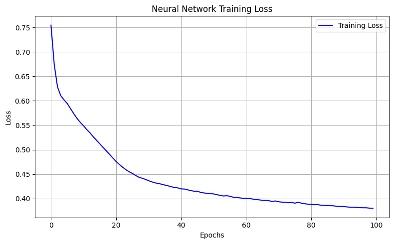

```
=============================================
DEEP LEARNING MODEL RESULTS
=============================================
Training Accuracy: 0.8441
Testing  Accuracy: 0.8045
Number of Layers : 4
Hidden Layers    : 64 neurons, 32 neurons
=============================================
```

```
FEATURE IMPORTANCE RANKING
=============================================
1. sex: 0.3492
2. fare_per_person: 0.1684
3. age: 0.1522
4. fare: 0.1495
5. pclass: 0.0903
6. family_size: 0.043
7. sibsp: 0.0251
8. parch: 0.0149
9. is_alone: 0.0073
=============================================
```

# **This Final Plot Shows off:**

**`8. Which Information Matters Most? (Feature Importance)`**

**What it is:**

This chart acts like a "Leaderboard." It ranks all the different pieces of information (like Age, Gender, and Ticket Price) to show which ones helped the computer make the most accurate guesses.

**The Bars:**

You will see a list of categories on one side, with bars of different lengths next to them.

**The Story:**

A longer bar means that specific piece of information was very important for predicting survival. For example, "Sex" usually has the longest bar because it was the biggest clue in deciding who lived or died. Short bars represent information that didn't help the computer very much.  
**Why it's important:**

It helps us focus on the "key factors" of the disaster. Instead of looking at every tiny detail, we can use this chart to identify the 3 or 4 main reasons why certain passengers were saved.

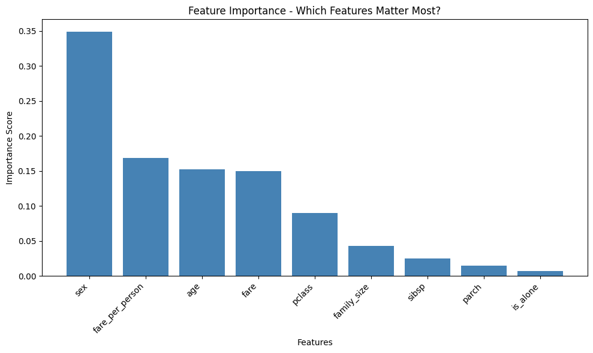

[output not shown]